# Linear Algebra

MSDA - Bootcamp 2026 Summer

Author

KT Wong

Published

Jul 27, 2026

Abstract

The materials in this topic are drawn from Stachurski (2016)

## Outline

1. Vectors
2. Matrix operations
3. Linear Transformation
4. System of Linear Equations
5. Vector Spaces
6. Eigenvalues and Eigenvectors
7. Applications for calculus

## Vectors

- A **vector** of length $n$ is just a sequence of $n$ numbers
  - $x=(x_1, \ldots, x_n)$ or
  - $x=\begin{bmatrix}x_1, \ldots, x_n\end{bmatrix}$
- vectors in 2-D space

. . .

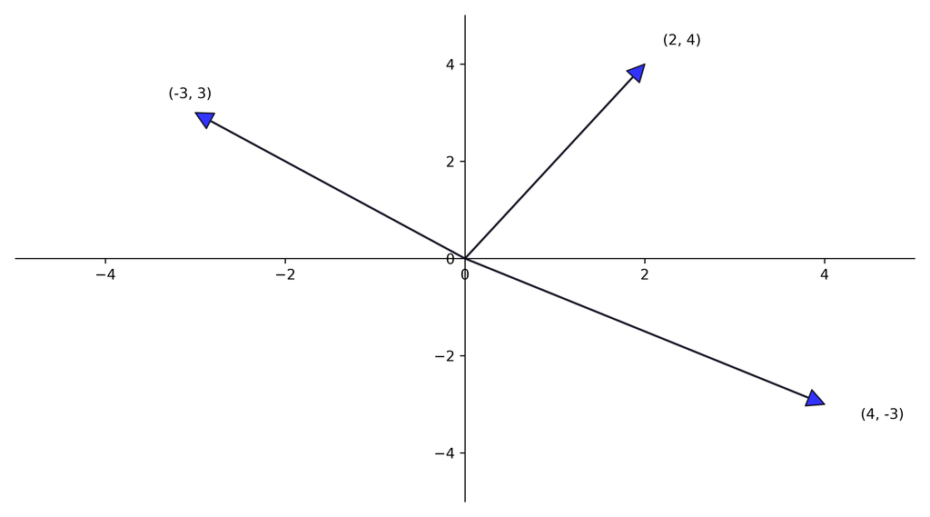

## Vectors

- row vector

. . .

$$u=\begin{bmatrix} 1 & 0 \end{bmatrix}$$

- column vector

. . .

$$v=\begin{bmatrix} 1 \\ 0 \end{bmatrix}$$

- $v=u^T$

## Vector Operations

- addition and subtraction
  - do the operation element-by-element
  - check the dimension of the vectors

. . .

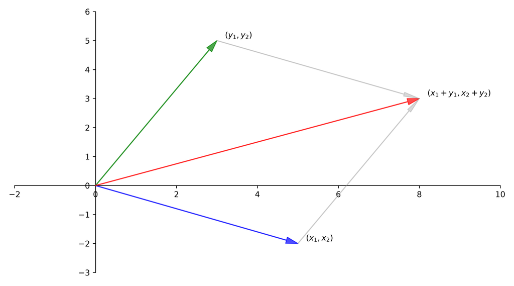

## Vector Operations

- vector multiplication
  - multiply vectors with scalars
  - dot product (inner product)

. . .

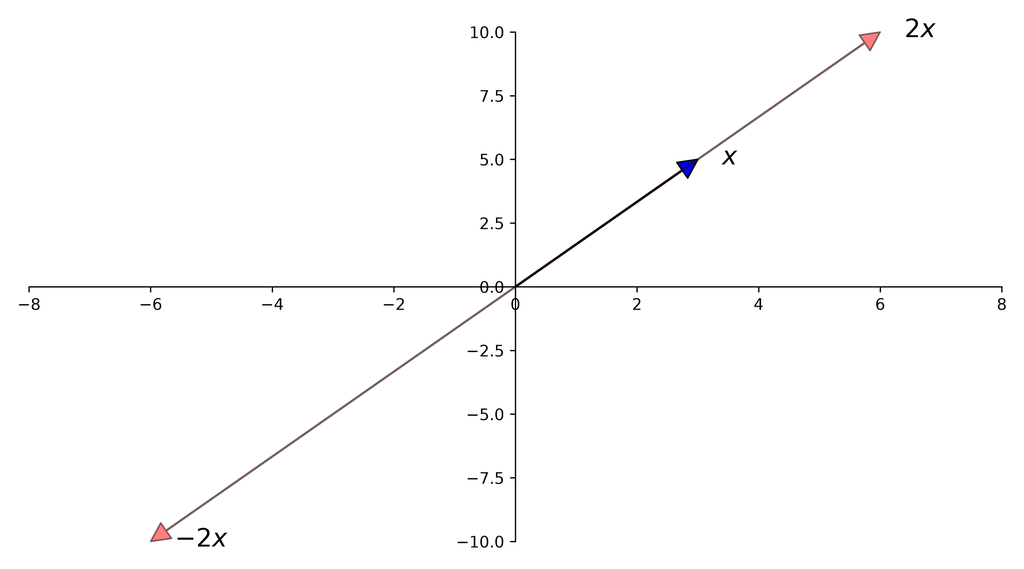

## Vector Operations

The [**dot product**](https://www.mathsisfun.com/algebra/vectors-dot-product.html) of vectors $x,y \in \mathbb R^n$ is defined as

. . .

$$\begin{array}{rl}
x^\top y &= {\color{red}{x_1 y_1}} + {\color{blue}{x_2 y_2}} + \cdots + x_n y_n \\
&= \sum_{i=1}^n x_i y_i
\end{array}$$

- the dot product could be written as $x \cdot y$ or $x'y$
- the dot product could be expressed in cosine form

. . .

$$x \cdot y = \|x\| \|y\| \cos \theta$$

## Matrix Algebra

- what is a matrix?
  - a matrix is a rectangular array of numbers
  - $A_{m \times n} = \begin{bmatrix} a_{11} & a_{12} & \cdots & a_{1n} \\ a_{21} & a_{22} & \cdots & a_{2n} \\ \vdots & \vdots & \ddots & \vdots \\ a_{m1} & a_{m2} & \cdots & a_{mn} \end{bmatrix}$

## Matrix Algebra

- matrix addition and subtraction
  - $A_{m \times n} \pm B_{m \times n} = C_{m \times n}$
    - e.g. $A = \begin{bmatrix} 1 & 2 \\ 3 & 4 \end{bmatrix}$, $B = \begin{bmatrix} 5 & 6 \\ 7 & 8 \end{bmatrix}$, $A+B = \begin{bmatrix} 6 & 8 \\ 10 & 12 \end{bmatrix}$
  - check the dimension of the matrices
- In general,

. . .

$$A + B =
\begin{bmatrix}
a_{11} & \cdots & a_{1k} \\
\vdots & \vdots & \vdots \\
a_{n1} & \cdots & a_{nk}
\end{bmatrix} +
\begin{bmatrix}
b_{11} & \cdots & b_{1k} \\
\vdots & \vdots & \vdots \\
b_{n1} & \cdots & b_{nk}
\end{bmatrix} =
\begin{bmatrix}
a_{11} + b_{11} & \cdots & a_{1k} + b_{1k} \\
\vdots & \vdots & \vdots \\
a_{n1} + b_{n1} & \cdots & a_{nk} + b_{nk}
\end{bmatrix}$$

## Matrix Algebra

- scale multiplication
  - In general for a number $\gamma$ and any matrix $A$,

. . .

$$\gamma A =
\gamma
\begin{bmatrix}
a_{11} & \cdots & a_{1k} \\
\vdots & \vdots & \vdots \\
a_{n1} & \cdots & a_{nk}
\end{bmatrix} :=
\begin{bmatrix}
\gamma a_{11} & \cdots & \gamma a_{1k} \\
\vdots & \vdots & \vdots \\
\gamma a_{n1} & \cdots & \gamma a_{nk}
\end{bmatrix}$$

## Matrix multiplication

- The rule for matrix multiplication generalizes the idea of inner products
  - If $A$ is $n \times k$ and $B$ is $j \times m$, then to multiply $A$ and $B$
    - any requirement on the dimensions of $A$ and $B$ for the matrix multiplication?
    - what will be dimension of the resulting matrix $A B$
- Here’s an example of a $2 \times 2$ matrix multiplied by a $2 \times 1$ vector

. . .

$$Ax =
\begin{bmatrix}
\color{red}{a_{11}} & \color{red}{a_{12}} \\
a_{21} & a_{22}
\end{bmatrix}
\begin{bmatrix}
\color{red}{x_1} \\
\color{red}{x_2}
\end{bmatrix}
=
\begin{bmatrix}
\color{red}{a_{11}x_1 + a_{12}x_2} \\
a_{21}x_1 + a_{22}x_2
\end{bmatrix}$$

- Here is a simple illustration of multiplication of two matrices

. . .

$$AB =
\begin{bmatrix}
a_{11} & a_{12} \\
\color{red}{a_{21}} & \color{red}{a_{22}} \\
\end{bmatrix}
\begin{bmatrix}
b_{11} & \color{red}{b_{12}} \\
b_{21} & \color{red}{b_{22}} \\
\end{bmatrix} :=
\begin{bmatrix}
a_{11}b_{11} + a_{12}b_{21} & a_{11}b_{12} + a_{12}b_{22} \\
a_{21}b_{11} + a_{22}b_{21} & \color{red}{a_{21}b_{12} + a_{22}b_{22}}
\end{bmatrix}$$

## Matrix multiplication

- Notice that $AB \neq BA$ in general
- There are many tutorials to help you further visualize this operation, like [this one](http://www.mathsisfun.com/algebra/matrix-multiplying.html)
- One important special case is the [identity matrix](https://en.wikipedia.org/wiki/Identity_matrix), which has ones on the principal diagonal and zero elsewhere:

. . .

$$I = \begin{bmatrix}
1 & \cdots & 0 \\
\vdots & \ddots & \vdots \\
0 & \cdots & 1
\end{bmatrix}$$

- Execises:
  - if $A$ is $n \times k$ and $I$ is the $k \times k$ identity matrix, then $AI = A$
  - if $I$ is the $n \times n$ identity matrix, then $IA = A$

## Exercise

$$Y=\begin{bmatrix} 3 & 1 & -2 \\ 6 & 3 & 4 \end{bmatrix}
, \quad X=\begin{bmatrix} 4 & 2 \\ 3 & 0 \\ 1 & 2 \end{bmatrix}$$

1. What are the dimensions of the matrices $X$ and $Y$?
2. How to multiply $Y$ and $X$ to yield a $3 \times 3$ matrix? Compute it
3. How to multiply $Y$ and $X$ to yield a $2 \times 2$ matrix? Compute it

## Linear Transformation

Matrics as Mapping

- Each $n \times k$ matrix $A$ can be identified with a function $f(x) = Ax$ that maps $x \in \mathbb R ^k$ into $y = Ax \in \mathbb R ^n$
  - these kinds of functions have a special property: they are *linear*
- A function $f \colon \mathbb R ^k \to \mathbb R ^n$ is called *linear* if
  - for all $x, y \in \mathbb R$ and all scalars $\alpha, \beta$, we have

$$f(\alpha x + \beta y) = \alpha f(x) + \beta f(y)$$

- it can be [shown](https://en.wikipedia.org/wiki/Linear_map#Matrices) that $f$ is linear *if and only if* there exists a matrix $A$ such that $f(x) = Ax$ for all $x$

## Linear Transformation

Some examples

We consider how a given matrix transforms in $\mathbb R ^2$

Let $\begin{bmatrix} 2 & 1 \\ -1 & 1 \end{bmatrix}$

- it transforms the vector $x = \begin{bmatrix} 1 \\ 3 \end{bmatrix}$ to the vector $y = \begin{bmatrix} 5 \\ 2 \end{bmatrix}$ through the matrix multiplication

$$\begin{bmatrix}
2 & 1 \\
-1 & 1
\end{bmatrix}
\begin{bmatrix}
1 \\
3
\end{bmatrix}$$

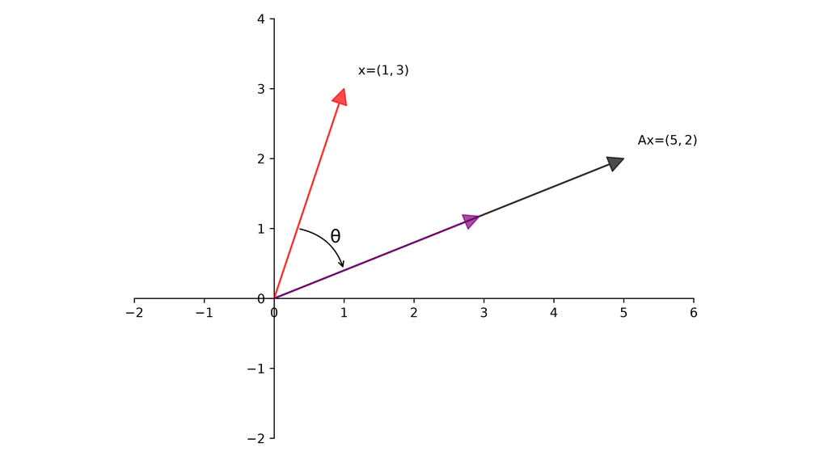

- Ex: with the same vector $x$, now, the matrix becomes $A = \begin{bmatrix} 1 & 2 \\ 3 & 4 \end{bmatrix}$, what will be the $y$?

## Linear Transformation

Some examples - Scaling

A matrix of the form

$$\begin{bmatrix}
\alpha & 0
\\ 0 & \beta
\end{bmatrix}$$

scales vectors across the x-axis by a factor $\alpha$ and along the y-axis by a factor $\beta$

- a simple example where $\alpha = \beta = 3$

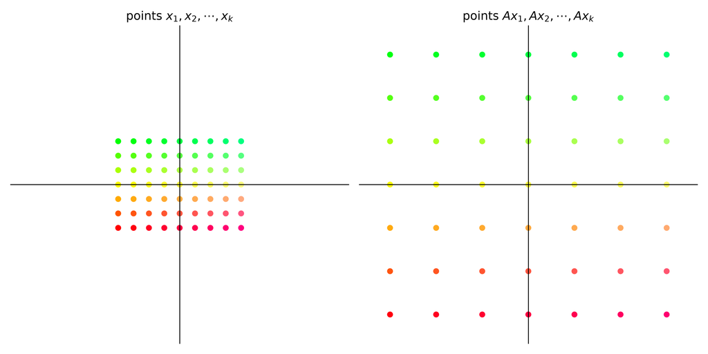

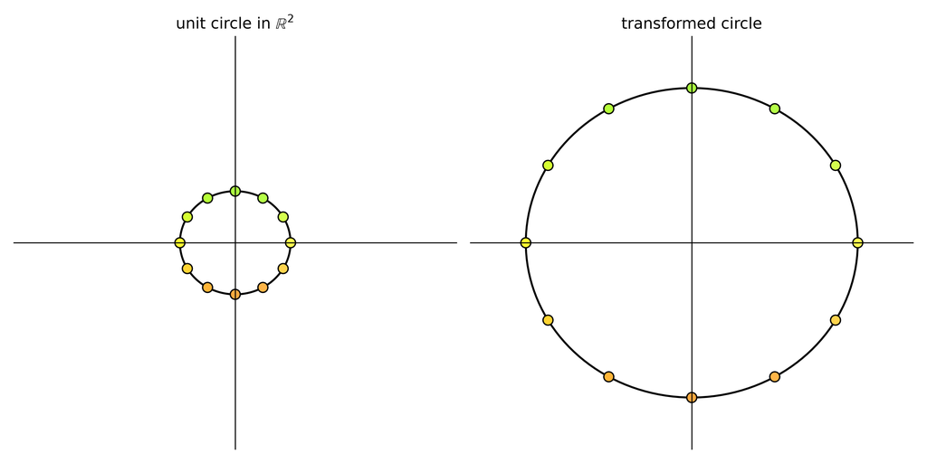

## Linear Transformation

Some examples - Shearing

A “shear” matrix of the form

$$\begin{bmatrix}
1 & \lambda \\
0 & 1
\end{bmatrix}$$

stretches vectors along the x-axis by an amount proportional to the y-coordinate of a point

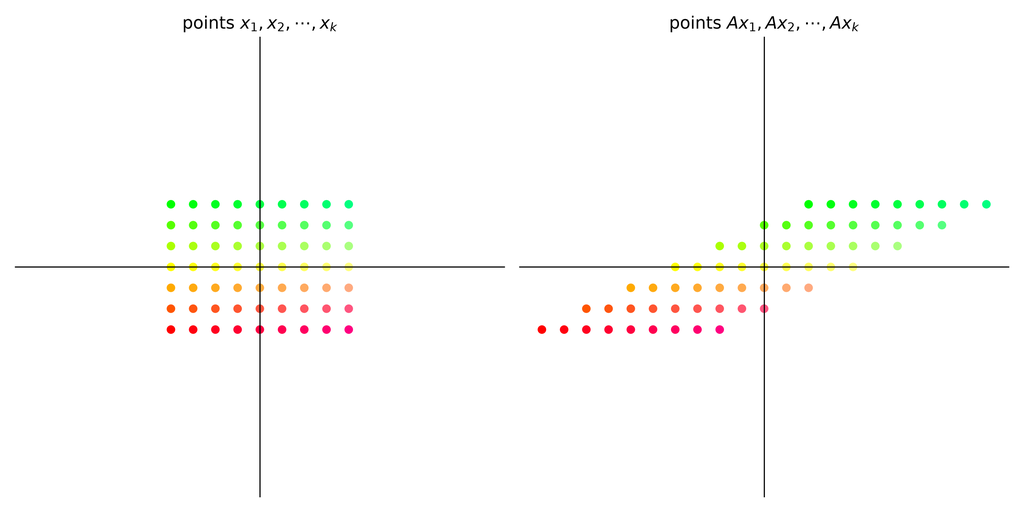

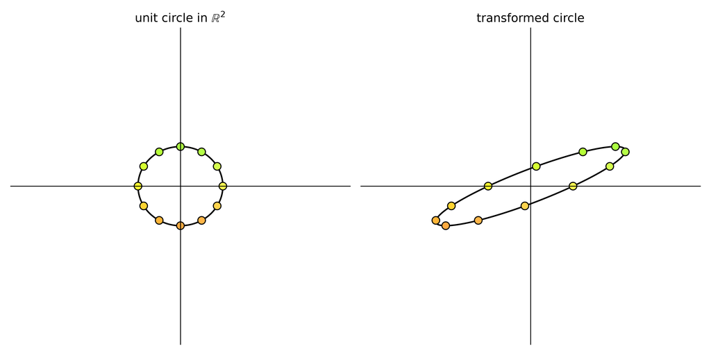

## Linear Transformation

Some examples - Rotation

A matrix of the form

$$\begin{bmatrix}
\cos \theta & \sin \theta
\\ - \sin \theta & \cos \theta
\end{bmatrix}$$

is called a *rotation matrix*

- This matrix rotates vectors clockwise by an angle $\theta$
  - 45 degree clockwise rotation

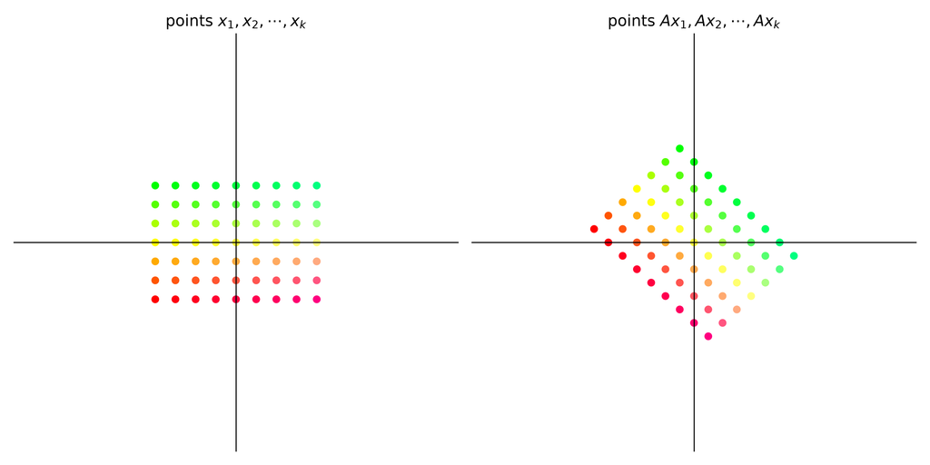

## Linear Transformation

Some examples - Permutation

The permutation matrix

$$\begin{bmatrix}
0 & 1 \\
1 & 0
\end{bmatrix}$$

interchanges the coordinates of a vector

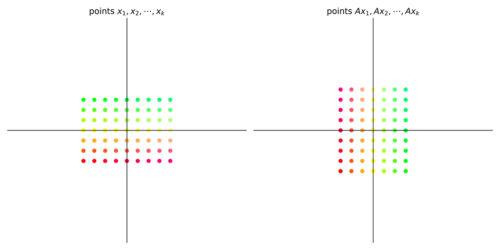

## Matrix multiplication as composition

Linear compositions

Consider the two matrices

$$A =
\begin{bmatrix}
0 & 1 \\
-1 & 0
\end{bmatrix}
\quad \text{and} \quad
B =
\begin{bmatrix}
1 & 2 \\
0 & 1
\end{bmatrix}$$

- What will the output be when we try to obtain $ABx$ for some $2 \times 1$ vector $x$?

. . .

$$\color{red}{\underbrace{
\color{black}{\begin{bmatrix}
0 & 1 \\
-1 & 0
\end{bmatrix}}
}_{\textstyle A} }
\color{red}{\underbrace{
\color{black}{\begin{bmatrix}
1 & 2 \\
0 & 1
\end{bmatrix}}
}_{\textstyle B}}
\color{red}{\overbrace{
\color{black}{\begin{bmatrix}
1 \\
3
\end{bmatrix}}
}^{\textstyle x}}
\rightarrow
\color{red}{\underbrace{
\color{black}{\begin{bmatrix}
0 & 1 \\
-1 & -2
\end{bmatrix}}
}_{\textstyle AB}}
\color{red}{\overbrace{
\color{black}{\begin{bmatrix}
1 \\
3
\end{bmatrix}}
}^{\textstyle x}}
\rightarrow
\color{red}{\overbrace{
\color{black}{\begin{bmatrix}
3 \\
-7
\end{bmatrix}}
}^{\textstyle y}}$$

## Matrix multiplication as composition

Linear compositions

$$\color{red}{\underbrace{
\color{black}{\begin{bmatrix}
0 & 1 \\
-1 & 0
\end{bmatrix}}
}_{\textstyle A} }
\color{red}{\underbrace{
\color{black}{\begin{bmatrix}
1 & 2 \\
0 & 1
\end{bmatrix}}
}_{\textstyle B}}
\color{red}{\overbrace{
\color{black}{\begin{bmatrix}
1 \\
3
\end{bmatrix}}
}^{\textstyle x}}
\rightarrow
\color{red}{\underbrace{
\color{black}{\begin{bmatrix}
0 & 1 \\
-1 & 0
\end{bmatrix}}
}_{\textstyle A}}
\color{red}{\overbrace{
\color{black}{\begin{bmatrix}
7 \\
3
\end{bmatrix}}
}^{\textstyle Bx}}
\rightarrow
\color{red}{\overbrace{
\color{black}{\begin{bmatrix}
3 \\
-7
\end{bmatrix}}
}^{\textstyle y}}$$

- We can observe that applying the transformation $AB$ on the vector $x$ is the same as first applying $B$ on $x$ and then applying $A$ on the vector $Bx$.
- the matrix product $AB$ is the composition of the matrix transformations $A$ and $B$
  - first apply transformation $B$ and then transformation $A$
- When we matrix multiply an $n \times m$ matrix $A$ with an $m \times k$ matrix $B$ the obtained matrix product is an $n \times k$ matrix $AB$

Thus, if $A$ and $B$ are transformations such that $A \colon \mathbb{R}^m \to \mathbb{R}^n$ and $B \colon \mathbb{R}^k \to \mathbb{R}^m$, then $AB$ transforms $\mathbb{R}^k$ to $\mathbb{R}^n$.

- notice that $AB$ is generally not equal to $BA$

## Matrix multiplication as composition

Linear compositions - examples

- Let $A$ be the $90^{\circ}$ clockwise rotation matrix given by $\begin{bmatrix} 0 & 1 \\ -1 & 0 \end{bmatrix}$
- Let $B$ be a shear matrix along the x-axis given by $\begin{bmatrix} 1 & 2 \\ 0 & 1 \end{bmatrix}$
- visualize how a grid of points changes when we apply the transformation $AB$ and then compare it with the transformation $BA$

## Matrix multiplication as composition

Linear compositions - examples

Shear then rotate

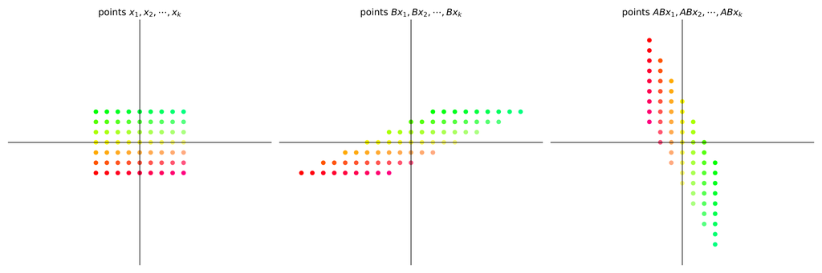

## Matrix multiplication as composition

Linear compositions - examples

Rotate then shear

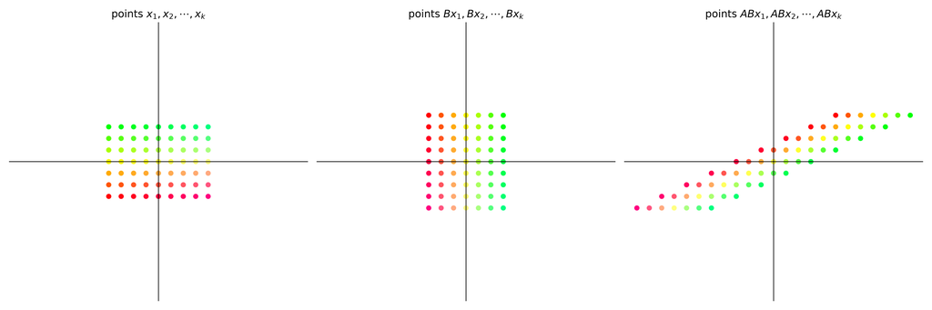

- it demonstrates that the transformation $AB$ is not the same as the transformation $BA$

## Matrix multiplication as composition

Linear compositions - Iterating on a fixed map

In economics, we are often interested in analyzing behavior where we repeatedly apply a fixed matrix

For example, given a vector $v$ and a matrix $A$, we are interested in studying the sequence

$$v, \quad
Av, \quad
AAv = A^2v, \quad \ldots$$

## Matrix multiplication as composition

Linear compositions - Iterating on a fixed map

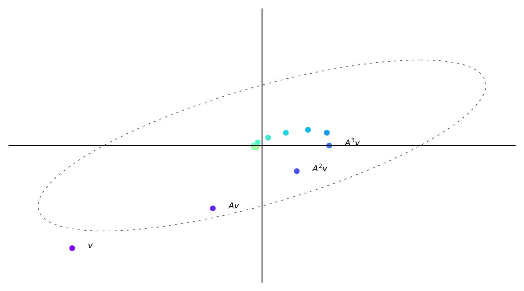

- Here with each iteration the vectors get shorter, i.e., move closer to the origin
- In this case, repeatedly multiplying a vector by $A$ makes the vector “spiral in”

## Matrix multiplication as composition

Linear compositions - Iterating on a fixed map

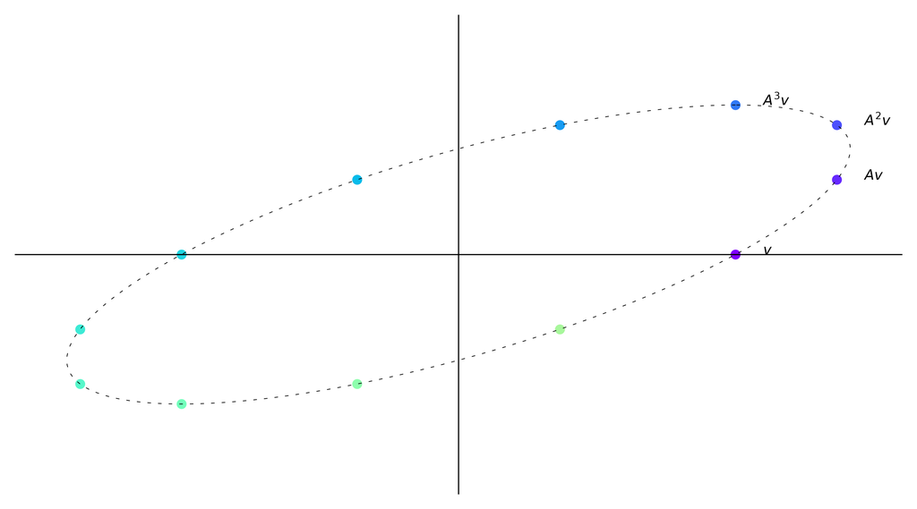

- In this case, repeatedly multiplying a vector by $A$ simply “rotates it around an ellipse”

## Matrix multiplication as composition

Linear compositions - Iterating on a fixed map

- Example of a sequence of iterates $(A^k v)_{k \geq 0}$ under map $A=\begin{bmatrix} \sqrt{3}+1 & -2 \\ 1 & \sqrt{3}-1 \end{bmatrix}$
- let $v = (-1, -0.25)$

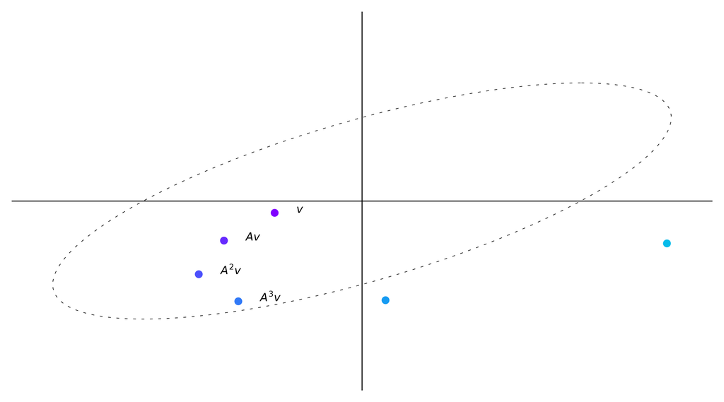

- In this case, repeatedly multiplying a vector by $A$ makes the vector “spiral out”

## System of Linear Equations

- Two equations in two unknowns

. . .

$$\begin{aligned}
y_1 = a x_1 + b x_2 \\
y_2 = c x_1 + d x_2
\end{aligned}$$

- How we solve it?
  - substitution and elimination
- Let us work on a simple example

. . .

$$\begin{aligned}
3x + 5y &= 7 \\
x - 2y &= 3
\end{aligned}$$

- what are $x$ and $y$?

## General linear systems

A more general version looks as follows

$$\begin{matrix}
a_{11} x_1 & + & a_{12} x_2 & + & \cdots & + & a_{1n} x_n & = & b_1 \\
\vdots & & \vdots & & & & \vdots & & \vdots \\
a_{n1} x_1 & + & a_{n2} x_2 & + & \cdots & + & a_{nn} x_n & = & b_n
\end{matrix}$$

- The objective here is to solve for the “unknowns” $x_1, \ldots, x_n$
- We take as given the coefficients $a_{11}, \ldots, a_{nn}$ and constants $b_1, \ldots, b_n$
- this is a setting where the number of unknowns equals the number of equations
  - this is the case where we are most likely to find a well-defined solution
- (The other cases are referred to as [overdetermined](https://en.wikipedia.org/wiki/Overdetermined_system) and [underdetermined](https://en.wikipedia.org/wiki/Underdetermined_system) systems of equations)

## Solving systems of equations

$$A x = b
\quad \text{where} \quad
A =
\begin{bmatrix}
a_{11} & \cdots & a_{1n} \\
\vdots & \vdots & \vdots \\
a_{n1} & \cdots & a_{nn}
\end{bmatrix}
\quad \text{and} \quad
b =
\begin{bmatrix}
b_1 \\
\vdots \\
b_n
\end{bmatrix}$$

- find a vector $x \in \mathbb R^n$ that solves the equations, taking $b$ and $A$ as given

## Some examples

Consider the system of equations given by

$$\begin{aligned}
x + 3y &= 3 \\
2x + 6y &= -8
\end{aligned}$$

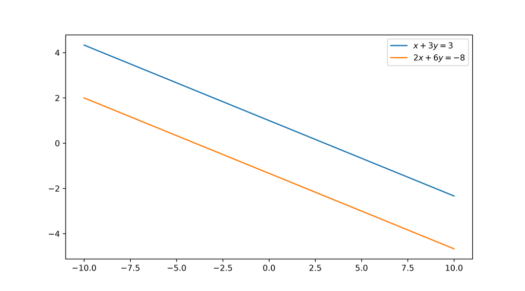

- the rows of $A$ are called linearly dependent

## Some examples

Consider the system of equations given by

$$\begin{aligned}
x - 2y &= -4 \\
-2x + 4y &= 8
\end{aligned}$$

Any vector $v = (x,y)$ such that $x = 2y - 4$ will solve the above system

Since we can find infinite such vectors this system has infinitely many solutions

This is because the rows of the corresponding matrix are linearly dependent

## Nonsingular matrices

- A square matrix $A$ is nonsingular if and only if the rows and columns of $A$ are linearly independent
- To every square matrix we can assign a unique number called the [determinant](https://en.wikipedia.org/wiki/Determinant).
- For $2 \times 2$ matrices, the determinant is given by,

$$\begin{bmatrix}
\color{red}{a} & \color{blue}{b} \\
\color{blue}{c} & \color{red}{d}
\end{bmatrix}
=
{\color{red}{ad}} - {\color{blue}{bc}}$$

- the determinant of a $3 \times 3$ matrix

$$det \begin{bmatrix}
a & b & c \\
d & e & f \\
g & h & i
\end{bmatrix}
= a(ei - fh) - b(di - fg) + c(dh - eg)$$

- If the determinant of $A$ is not zero, then we say that $A$ is *nonsingular*
- The determinant of a $2 \times 2$ matrix is also the area of the parallelogram spanned by the column vectors
- The determinant of a $2 \times 2$ matrix is also the factor by which the matrix scales the area of any set of points in the plane
  - if the determinant is negative, the matrix also flips the orientation of the plane
  - if the determinant is zero, the matrix collapses the plane to a line or lower-dimensional space
  - if the determinant is one, the matrix preserves the area of the plane
  - if the determinant is greater than one, the matrix expands the area of the plane
  - if the determinant is less than one, the matrix shrinks the area of the plane

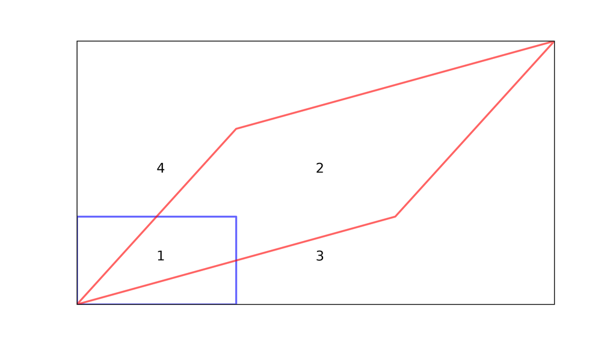

## Nonsingular matrices

- a square matrix $A$ has a nonzero determinant, if and only if it possesses an *inverse matrix* $A^{-1}$, with the property that $A A^{-1} =A^{-1} A = I$.
- As a consequence, if we pre-multiply both sides of $Ax = b$ by $A^{-1}$, we get

. . .

$$x = A^{-1} b$$

This is the solution to $Ax = b$ —– the solution we are looking for

- A more detailed explanation of matrix inverse can be found [here](https://www.mathsisfun.com/algebra/matrix-inverse.html)

## When the matrices have more rows than columns

$A_{n \times k}$ matrix with $n > k$

## When the matrices have more columns than rows

$A_{n \times k}$ matrix with $n < k$

- there are either no solutions or infinitely many — in other words, uniqueness never holds
- For example, consider the case where $k=3$ and $n=2$
  - the columns of $A$ consists of 3 vectors in $\mathbb R ^2$
  - this set can never be linearly independent
  - hence, one column is a linear combination of the other two
  - let’s say that $a_1 = \alpha a_2 + \beta a_3$
  - then if $y = Ax = x_1 a_1 + x_2 a_2 + x_3 a_3$, we can also write

. . .

$$y
= x_1 (\alpha a_2 + \beta a_3) + x_2 a_2 + x_3 a_3
= (x_1 \alpha + x_2) a_2 + (x_1 \beta + x_3) a_3$$

## Vector Spaces

### Span

- Given a set of vectors $A := \{a_1, \ldots, a_k\}$ in $\mathbb R ^n$
  - new vectors can be created by performing linear operations
- new vectors created in this manner are called *linear combinations* of $A$
- In particular, $y \in \mathbb R ^n$ is a linear combination of $A := \{a_1, \ldots, a_k\}$ if

$$y = \beta_1 a_1 + \cdots + \beta_k a_k, \quad
\text{ for some scalars } \beta_1, \ldots, \beta_k$$

- the values $\beta_1, \ldots, \beta_k$ are called the *coefficients* of the linear combination
- The set of linear combinations of $A$ is called the *span* of $A$

## Vector Spaces

### Span

The figure shows the span of $A = \{a_1, a_2\}$ in $\mathbb R ^3$

The span is a two-dimensional plane passing through these two points and the origin

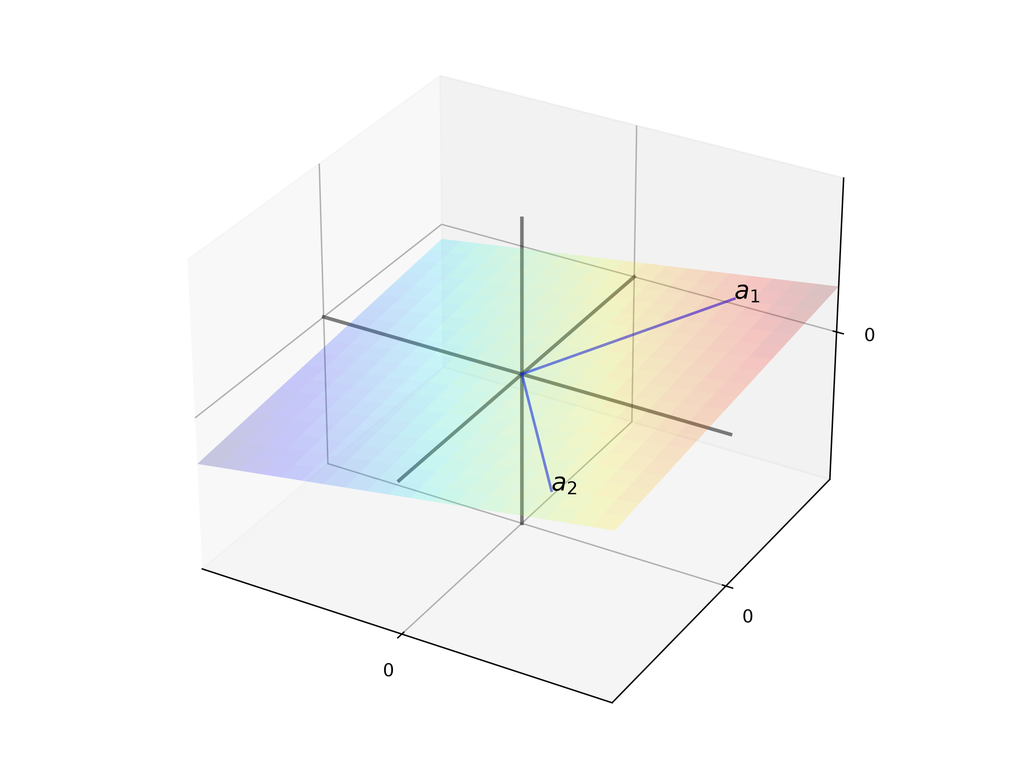

## Vector Spaces

### Span - Example

If $A = \{e_1, e_2, e_3\}$ consists of the *canonical basis vectors* of $\mathbb R ^3$, that is

$$e_1 :=
\begin{bmatrix}
1 \\
0 \\
0
\end{bmatrix}
, \quad
e_2 :=
\begin{bmatrix}
0 \\
1 \\
0
\end{bmatrix}
, \quad
e_3 :=
\begin{bmatrix}
0 \\
0 \\
1
\end{bmatrix}$$

then the span of $A$ is all of $\mathbb R ^3$, because, for any $x = (x_1, x_2, x_3) \in \mathbb R ^3$, we can write

$$x = x_1 e_1 + x_2 e_2 + x_3 e_3$$

- Exercise: Does $A_0 = \{e_1, e_2, e_1 + e_2\}$ span $\mathbb{R}^3$

## Vector Spaces

### Linear Independence (Re-cap)

- a collection of vectors $A := \{a_1, \ldots, a_k\}$ in $\mathbb R ^n$ is said to be
  - *linearly dependent* if some strict subset of $A$ has the same span as $A$
  - *linearly independent* if it is not linearly dependent
- Put differently, a set of vectors is linearly independent if no vector is redundant to the span and linearly dependent otherwise
- since $\mathbb R ^n$ can be spanned by $n$ vectors
  - any collection of $m > n$ vectors in $\mathbb R ^n$ must be linearly dependent
- The following statements are equivalent to linear independence of $A= \{a_1, \ldots, a_k\} \subset \mathbb R ^n$
  1. No vector in $A$ can be formed as a linear combination of the other elements
  2. If $\beta_1 a_1 + \cdots \beta_k a_k = 0$ for scalars $\beta_1, \ldots, \beta_k$, then $\beta_1 = \cdots = \beta_k = 0$

## Eigenvalues and Eigenvectors

Let $A$ be an $n \times n$ square matrix

If $\lambda$ is scalar and $v$ is a non-zero vector in $\mathbb R ^n$ such that

$$A v = \lambda v$$

then we say that $\lambda$ is an *eigenvalue* of $A$, and $v$ is an *eigenvector*

- an eigenvector of $A$ is a vector such that when the map $f(x) = Ax$ is applied
  - $v$ is merely scaled

## Positive Definite Matrices

Let $A$ be a symmetric $n \times n$ matrix

- $A$ is
  1. *positive definite* if $x' A x > 0$ for every $x \in \mathbb R ^n \setminus \{0\}$
  2. *positive semi-definite* or *nonnegative definite* if $x' A x \geq 0$ for every $x \in \mathbb R ^n$
- Analogous definitions exist for negative definite and negative semi-definite matrices
- if $A$ is positive definite, then all of its eigenvalues are strictly positive
  - hence $A$ is invertible (with positive definite inverse)

## Differentiating Linear and Quadratic Forms

The following formulas are useful in some statistics theory. Let

- $z, x$ and $a$ all be $n \times 1$ vectors
- $A$ be an $n \times n$ matrix
- $B$ be an $m \times n$ matrix and $y$ be an $m \times 1$ vector
- The we have the following:
  1. $\frac{\partial a' x}{\partial x} = a$
  2. $\frac{\partial A x}{\partial x} = A'$
  3. $\frac{\partial x'A x}{\partial x} = (A + A') x$
  4. $\frac{\partial y'B z}{\partial y} = B z$
  5. $\frac{\partial y'B z}{\partial B} = y z'$

## Generalized Eigenvalues

- It is sometimes useful to consider the *generalized eigenvalue problem*, which, for given matrices $A$ and $B$, seeks generalized eigenvalues $\lambda$ and eigenvectors $v$ such that

$$A v = \lambda B v$$

- This can be solved in SciPy via `scipy.linalg.eig(A, B)`.
- if $B$ is square and invertible, then we can treat the generalized eigenvalue problem as an ordinary eigenvalue problem $B^{-1} A v = \lambda v$, but this is not always the case

## Matrix Norms

Let $A$ be a square matrix, and let

$$\| A \| := \max_{\| x \| = 1} \| A x \|$$

- The norms on the right-hand side are ordinary vector norms, while the norm on the left-hand side is a *matrix norm*
  - it is also called *spectral norm*.
- For example, for a square matrix $S$, the condition $\| S \| < 1$ means that $S$ is *contractive*
  - it pulls all vectors towards the origin

## Neumann’s Theorem

Let $A$ be a square matrix and let $A^k := A A^{k-1}$ with $A^1 := A$

**NoteNeumann’s theorem**

Let $A$ be a square matrix and let $A^k$ be the $k$-th power of $A$ with $A^1 := A$,

Let $r(A)$ be the **spectral radius** of $A$, defined as $\max_i |\lambda_i|$, where

- $\{\lambda_i\}_i$ is the set of eigenvalues of $A$ and
- $|\lambda_i|$ is the modulus of the complex number $\lambda_i$

If $r(A) < 1$, then $I - A$ is invertible, and

$$(I - A)^{-1} = \sum_{k=0}^{\infty} A^k$$

## Spectral Radius

- A result known as Gelfand’s formula

For any square matrix $A$,

$$\rho(A) = \lim_{k \to \infty} \| A^k \|^{1/k}$$

- $\rho(A)$ is the *spectral radius*, defined as $\max_i |\lambda_i|$, where $\{\lambda_i\}_i$ is the set of eigenvalues of $A$
- if all eigenvalues are strictly less than one in modulus, there exists a $k$ with $\| A^k \| < 1$

## The Perron-Frobenius Theorem

### Nonnegative Matrices

- An $n \times m$ matrix $A$ is called **nonnegative** if every element of $A$ is nonnegative, i.e., $a_{ij} \geq 0$ for every $i,j$ — denoted as $A \geq 0$

### Irreducible matrices

- Let $a^{k}_{ij}$ be element $(i,j)$ of $A^k$
- An $n \times n$ nonnegative matrix $A$ is called **irreducible** if $A + A^2 + A^3 + \cdots \gg 0$, where $\gg 0$ indicates that every element in $A$ is strictly positive
  - for each $i,j$ with $1 \leq i, j \leq n$, there exists a $k \geq 0$ such that $a^{k}_{ij} > 0$
- Here are some examples for illustration:

$$A = \begin{bmatrix} 0.5 & 0.1 \\
0.2 & 0.2
\end{bmatrix}
, \quad
B = \begin{bmatrix} 0 & 1 \\
1 & 0
\end{bmatrix}
, \quad
C = \begin{bmatrix} 1 & 0 \\
0 & 1
\end{bmatrix}$$

- $A$ is irreducible since $a_{ij}>0$ for all $(i,j)$
- $B$ is irreducible since $B + B^2$ is a matrix of ones
- $C$ is not irreducible since $C^k = C$ for all $k \geq 0$ and thus $c^{k}_{12},c^{k}_{21} = 0$ for all $k \geq 0$

## The Perron-Frobenius Theorem

### Left eigenvectors

- A vector $w$ is called a left eigenvector of $A$ if $w$ is a right eigenvector of $A^\top$
  - if $w$ is a left eigenvector of matrix $A$, then $A^\top w = \lambda w$, where $\lambda$ is the eigenvalue associated with the left eigenvector $v$
- Left eigenvectors will play important roles in what follows, including that of stochastic steady states for dynamic models under a Markov assumption

## The Perron-Frobenius Theorem

**NoteThe Perron-Frobenius Theorem**

If a matrix $A\geq 0$, then

1. the dominant eigenvalue of $A$, $r(A)$ is real-valued and nonnegative
2. for any other eigenvalues $\lambda$ of $A$, $|\lambda| \leq r(A)$
3. we can find a nonnegative and nonzero eigenvector $v$ such that $A v = r(A) v$

In addition, if $A$ is irreducible, then

1. the eigenvector $v$ associated with eigenvector $r(A)$ is strictly positive
2. there exists no other positive eigenvector $v$ associated with $r(A)$
- For a square nonnegative matrix $A$, the behavior of $A^k$ as $k \to \infty$ is controlled by the eigenvalue with the largest absolute value, often called the **dominant eigenvalue**
- For any such matrix $A$, the Perron-Frobenius Theorem characterizes certain properties of the dominant eigenvalue and its corresponding eigenvector

## The Perron-Frobenius Theorem

### Primitive matrices

Let $A$ be a square nonnegative matrix and let $A^k$ be the $k^{th}$ power of $A$

A matrix is called **primitive** if there exists a $k \in \mathbb{N}$ such that $A^k$ is everywhere positive

- Recall the examples given in irreducible matrices:

$$A = \begin{bmatrix} 0.5 & 0.1 \\
0.2 & 0.2
\end{bmatrix}$$

## Perron-Frobenius Theorem

If $A$ is primitive then,

1. the inequality $|\lambda| \leq r(A)$ is **strict** for all eigenvalues $\lambda$ of $A$ distinct from $r(A)$, and
2. with $v$ and $w$ normalized so that the inner product of $w$ and $v = 1$, we have $r(A)^{-m} A^m$ converges to $v w^{\top}$ when $m \rightarrow \infty$
   - The matrix $v w^{\top}$ is called the **Perron projection** of $A$

## QR decomposition

The QR decomposition (also called the QR factorization) of a matrix is a decomposition of a matrix into the product of an orthogonal matrix and a triangular matrix.

A QR decomposition of a real matrix $A$ takes the form

$$A=QR$$

where

- $Q$ is an orthogonal matrix (so that $Q^TQ = I$)
- $R$ is an upper triangular matrix
- use a **Gram-Schmidt process** to compute a QR decomposition

## QR decomposition

### Gram-Schmidt process

Start with a **square** matrix $A$

If a square matrix $A$ is nonsingular, then a $QR$ factorization is unique

let

$$A= \left[ \begin{array}{c|c|c|c} a_1 & a_2 & \cdots & a_n \end{array} \right], \quad || · ||:= L2 \text{ norm }$$

The Gram-Schmidt algorithm repeatedly combines the following two steps in a particular order

- **normalize** a vector to have unit norm
- **orthogonalize** the next vector

To begin, we set $u_1 = a_1$ and then **normalize**:

$$u_1=a_1, \ \ \ e_1=\frac{u_1}{||u_1||}$$

We **orgonalize** first to compute $u_2$ and then **normalize** to create $e_2$:

$$u_2=a_2-(a_2· e_1)e_1, \ \ \ e_2=\frac{u_2}{||u_2||}$$

- $e_1$ is orthogonal to $e_2$ by checking that $e_1 \cdot e_2 = 0$

The Gram-Schmidt procedure continues iterating + for $k= 2, \ldots, n-1$ we construct

$$u_{k+1}=a_{k+1}-(a_{k+1}· e_1)e_1-\cdots-(a_{k+1}· e_k)e_k, \ \ \ e_{k+1}=\frac{u_{k+1}}{||u_{k+1}||}$$

Here $ (a_j e_i) $ can be interpreted as the linear least squares **regression coefficient** of $ a_j $ on $ e_i $

- it is the inner product of $ a_j $ and $ e_i $ divided by the inner product of $ e_i $ where $ e_i e_i = 1 $, as *normalization* has assured us.
- this regression coefficient has an interpretation as being a **covariance** divided by a **variance**

it can be verified that

$$A= \left[ \begin{array}{c|c|c|c} a_1 & a_2 & \cdots & a_n \end{array} \right]=
\left[ \begin{array}{c|c|c|c} e_1 & e_2 & \cdots & e_n \end{array} \right]
\left[ \begin{matrix} a_1·e_1 & a_2·e_1 & \cdots & a_n·e_1\\ 0 & a_2·e_2 & \cdots & a_n·e_2
\\ \vdots & \vdots & \ddots & \vdots \\ 0 & 0 & \cdots & a_n·e_n \end{matrix} \right]$$

Thus, we have constructed the decomposision

$$A = Q R$$

where

$$Q = \left[ \begin{array}{c|c|c|c} a_1 & a_2 & \cdots & a_n \end{array} \right]=
\left[ \begin{array}{c|c|c|c} e_1 & e_2 & \cdots & e_n \end{array} \right]$$

and

$$R = \left[ \begin{matrix} a_1·e_1 & a_2·e_1 & \cdots & a_n·e_1\\ 0 & a_2·e_2 & \cdots & a_n·e_2
\\ \vdots & \vdots & \ddots & \vdots \\ 0 & 0 & \cdots & a_n·e_n \end{matrix} \right]$$

## QR decomposition

### Gram-Schmidt process

suppose that $A$ is an $n \times m$ matrix where $m > n$

Then a $QR$ decomposition is

$$A= \left[ \begin{array}{c|c|c|c} a_1 & a_2 & \cdots & a_m \end{array} \right]=\left[ \begin{array}{c|c|c|c} e_1 & e_2 & \cdots & e_n \end{array} \right]
\left[ \begin{matrix} a_1·e_1 & a_2·e_1 & \cdots & a_n·e_1 & a_{n+1}\cdot e_1 & \cdots & a_{m}\cdot e_1 \\
0 & a_2·e_2 & \cdots & a_n·e_2 & a_{n+1}\cdot e_2 & \cdots & a_{m}\cdot e_2 \\ \vdots & \vdots & \ddots & \quad \vdots & \vdots & \ddots & \vdots
\\ 0 & 0 & \cdots & a_n·e_n & a_{n+1}\cdot e_n & \cdots & a_{m}\cdot e_n \end{matrix} \right]$$

which implies that

$$\begin{align*}
a_1 & = (a_1\cdot e_1) e_1 \cr
a_2 & = (a_2\cdot e_1) e_1 + (a_2\cdot e_2) e_2 \cr
\vdots & \quad \vdots \cr
a_n & = (a_n\cdot e_1) e_1 + (a_n\cdot e_2) e_2 + \cdots + (a_n \cdot e_n) e_n \cr
a_{n+1} & = (a_{n+1}\cdot e_1) e_1 + (a_{n+1}\cdot e_2) e_2 + \cdots + (a_{n+1}\cdot e_n) e_n \cr
\vdots & \quad \vdots \cr
a_m & = (a_m\cdot e_1) e_1 + (a_m\cdot e_2) e_2 + \cdots + (a_m \cdot e_n) e_n \cr
\end{align*}$$

```python
import numpy as np
from scipy.linalg import qr

def QR_Decomposition(A):
    n, m = A.shape # get the shape of A

    Q = np.empty((n, n)) # initialize matrix Q
    u = np.empty((n, n)) # initialize matrix u

    u[:, 0] = A[:, 0]
    Q[:, 0] = u[:, 0] / np.linalg.norm(u[:, 0])

    for i in range(1, n):

        u[:, i] = A[:, i]
        for j in range(i):
            u[:, i] -= (A[:, i] @ Q[:, j]) * Q[:, j] # get each u vector

        Q[:, i] = u[:, i] / np.linalg.norm(u[:, i]) # compute each e vetor

    R = np.zeros((n, m))
    for i in range(n):
        for j in range(i, m):
            R[i, j] = A[:, j] @ Q[:, i]

    return Q, R

def diag_sign(A):
    "Compute the signs of the diagonal of matrix A"

    D = np.diag(np.sign(np.diag(A)))

    return D

def adjust_sign(Q, R):
    """
    Adjust the signs of the columns in Q and rows in R to
    impose positive diagonal of Q
    """

    D = diag_sign(Q)

    Q[:, :] = Q @ D
    R[:, :] = D @ R

    return Q, R

A = np.array([[1.0, 1.0, 0.0], [1.0, 0.0, 1.0], [0.0, 1.0, 1.0]])
# A = np.array([[1.0, 0.5, 0.2], [0.5, 0.5, 1.0], [0.0, 1.0, 1.0]])
# A = np.array([[1.0, 0.5, 0.2], [0.5, 0.5, 1.0]])

A

Q, R = adjust_sign(*QR_Decomposition(A))

Q

R

Q_scipy, R_scipy = adjust_sign(*qr(A))

print('Our Q: \n', Q)
print('\n')
print('Scipy Q: \n', Q_scipy)
```

[output not shown]

## Singular Value Decomposition

A **singular value decomposition** of an $m \times n$ matrix $X$ of rank $p \leq \min(m,n)$ is

$$X = U \Sigma V^\top$$

where

$$\begin{aligned}
UU^\top & = I & \quad U^\top U = I \cr
VV^\top & = I & \quad V^\top V = I
\end{aligned}$$

and

- $U$ is an $m \times m$ orthogonal matrix of **left singular vectors** of $X$
- Columns of $U$ are eigenvectors of $X X^\top$
- $V$ is an $n \times n$ orthogonal matrix of **right singular vectors** of $X$
- Columns of $V$ are eigenvectors of $X^\top X$
- $\Sigma$ is an $m \times n$ matrix in which the first $p$ places on its main diagonal are positive numbers $\sigma_1, \sigma_2, \ldots, \sigma_p$ called **singular values**; remaining entries of $\Sigma$ are all zero
- The $p$ singular values are positive square roots of the eigenvalues of the $m \times m$ matrix $X X^\top$ and also of the $n \times n$ matrix $X^\top X$
- We adopt a convention that when $U$ is a complex valued matrix, $U^\top$ denotes the **conjugate-transpose** or **Hermitian-transpose** of $U$, meaning that $U_{ij}^\top$ is the complex conjugate of $U_{ji}$.
- Similarly, when $V$ is a complex valued matrix, $V^\top$ denotes the **conjugate-transpose** or **Hermitian-transpose** of $V$

## Applications in Calculus

### Revisit the optimization problem

- Suppose we have a function $f: \mathbb{R}^n \to \mathbb{R}$ that is twice continuously differentiable. If $x^*$ is a local minimizer/maximizer of $f$, then the gradient of $f$ at $x^*$ is zero,

$$\nabla f(x^*) = 0 \quad \text{ i.e. } \begin{bmatrix} \frac{\partial f}{\partial x_1} \\ \vdots \\ \frac{\partial f}{\partial x_n} \end{bmatrix} = \begin{bmatrix} 0 \\ \vdots \\ 0 \end{bmatrix}$$

- Exercise
  - Find the gradient of the function $f(x, y) = 8x^3 + 2xy - -3x^2 + y^2 + 1$
- (0,0) and (1/3, -1/3) are the critical points of the function

## Applications in Calculus

### Revisit the optimization problem

- Let A be a symmetric $n × n$ matrix
- The matrix A is positive definite if $x' A x > 0$ for every $x \in \mathbb R ^n \setminus \{0\}$
  - it is positive semi-definite if $x' A x \geq 0$ for every $x \in \mathbb R ^n$
- The matrix A is negative definite if $x' A x < 0$ for every $x \in \mathbb R ^n \setminus \{0\}$
  - it is negative semi-definite if $x' A x \leq 0$ for every $x \in \mathbb R ^n$
- The matrix A is indefinite if there exist $x, y \in \mathbb R ^n$ such that $x' A x > 0$ and $y' A y < 0$

## Applications in Calculus

### Revisit the optimization problem

- A minor of A of order k is a determinant of a $k × k$ sub-matrix of A
- A minor of matrix $A$ of order $k$ is principal if it is obtained by deleting $n − k$ rows and the $n − k$ columns with the same numbers
- The leading principal minor of A of order k is the minor of order k obtained by deleting the `last` $n − k$ rows and columns
- The leading principal minors of a matrix are the determinants of the leading principal minors
- Exercise
  - Find the leading principal minors of the matrix $A = \begin{pmatrix} a & b \\ b & c \end{pmatrix}$
    - show that the matrix is positive definite if $a > 0$ and $ac > b^2$
  - Find the leading principal minors of the matrix $A = \begin{pmatrix} 1 & 0 & 2 \\ 0 & 2 & 4 \\ 0 & 2 & 2 \end{pmatrix}$
- Let A be an m × n matrix. The rank of A is the maximal order of a non-zero minor of A
- the leading principal minors are $D_1 = a$ and $D_2 = ac − b^2$ for the $2 \times 2$ symmetric matrix

## Applications in Calculus

### Revisit the optimization problem

- Let us consider $n=2$ and $f: \mathbb{R}^2 \to \mathbb{R}$ for some intuition first
- The Hessian matrix of $f$ at $x^*$ is the matrix of second partial derivatives of $f$ at $x^*$

$$H(x^*) = \begin{bmatrix} \frac{\partial^2 f}{\partial x_1^2} & \frac{\partial^2 f}{\partial x_1 \partial x_2} \\ \frac{\partial^2 f}{\partial x_2 \partial x_1} & \frac{\partial^2 f}{\partial x_2^2} \end{bmatrix}$$

## Applications in Calculus

### Revisit the optimization problem

- The matrix associated with the Langrange multiplier method is

$$\begin{bmatrix} 0 & \nabla g(x) \\ \nabla g(x) & \nabla^2 f(x) \end{bmatrix}$$

- the matrix is called the bordered Hessian matrix, $\bar{H}$
- For a function $f: \mathbb{R}^2 \to \mathbb{R}$ and a constraint $g: \mathbb{R}^2 \to \mathbb{R}$, le the Lagrangian be $L(x, y, \lambda) = f(x, y) - \lambda g(x, y)$
- the bordered Hessian matrix is

$$\begin{bmatrix} 0 & \nabla g(x) \\ \nabla g(x) & \nabla^2 f(x) \end{bmatrix} = \begin{bmatrix} 0 & \frac{\partial g}{\partial x} & \frac{\partial g}{\partial y} \\ \frac{\partial g}{\partial x} & \frac{\partial L}{\partial x^2 } & \frac{\partial L}{\partial x \partial y} \\ \frac{\partial g}{\partial y} & \frac{\partial L}{\partial y \partial x} & \frac{\partial L}{\partial y^2 } \end{bmatrix}$$

- Exercise:
  - Find the bordered Hessian matrix of the function $f(x, y) = -ax^2 -by^2$ subject to the constraint $x + y= 1$ where $a, b >0$
- The bordered Hessian matrix is $\begin{bmatrix} 0 & 1 & 1 \\ 1 & -2a & 0 \\ 1 & 0 & -2b \end{bmatrix}$
  - the leading principal minors are 0, $-1$, and $2(a+b)$
  - the critical point is $(x^*_1, x^*_2, \lambda^*)= (\frac{b}{a+b}, \frac{a}{a+b}, -\frac{2ab}{a+b})$
  - the critical point is a local maximum
- Ex: Find the bordered Hessian matrix of the function $f(x, y) = -ax^2 -by^2$ subject to the constraint $x + y= 1$ where $a, b >0$

## Applications in Calculus

### Revisit the optimization problem

- consider a general function $f: \mathbb{R}^n \to \mathbb{R}$ and a constraint $g_j: \mathbb{R}^n \to \mathbb{R}, j=1, \dots,m$
- the Lagrangian is $L(x, \lambda) = f(x) - \sum_{j=1}^m \lambda_j g_j(x)$
- the bordered Hessian matrix is

$$\begin{bmatrix} 0 & \cdots & 0 & \frac{\partial g_1(\cdot)}{\partial x_1} & \cdots & \frac{\partial g_1(\cdot)}{\partial x_n}\\ \vdots & \ddots & \vdots & \vdots & \ddots & \vdots \\
0 & \cdots & 0 & \frac{\partial g_m(\cdot)}{\partial x_1} & \cdots & \frac{\partial g_m(\cdot)}{\partial x_n} \\
\frac{\partial g_1(\cdot)}{\partial x_1} & \cdots & \frac{\partial g_m(\cdot)}{\partial x_1} & \frac{\partial^2 L(\cdot)}{\partial x_1^2} & \cdots & \frac{\partial^2 L(\cdot)}{\partial x_1 \partial x_n} \\
\vdots & \ddots & \vdots & \vdots & \ddots & \vdots \\
\frac{\partial g_1(\cdot)}{\partial x_n} & \cdots & \frac{\partial g_m(\cdot)}{\partial x_n} & \frac{\partial^2 L(\cdot)}{\partial x_n \partial x_1} & \cdots & \frac{\partial^2 L(\cdot)}{\partial x_n^2} \\
\end{bmatrix}$$

## Applications in Calculus

### Revisit the optimization problem

- Let $(x^*, \lambda^*)$ solve the FOC of the Lagrangian, then
  - $X^*$ is a local minimizer if the bordered Hessian matrix is positive definite
    - $|\bar{H}_{2m}|$ and all the leading principal minors have the same sign as $(-1)^m$
  - $X^*$ is a local maximizer if the bordered Hessian matrix is negative definite
    - $|\bar{H}_{2m}|$ has the same sign as $(-1)^m$ and the leading principal minors alternate in sign thereafter
- The first $m$ leading principle minors are zero matrices (every element of the matrix, $|\bar{H}_1|$ through $|\bar{H}_m|$ is zero) • The next $m − 1$ leading principle minors will have a determinant of zero (every element of the matrix, $|\bar{H}_{m+1}|$ through $|\bar{H}_{2m-1}|$ is zero)
- For example:
  - 0 Borders: −; +; −; + : : : (max) or +; +; +; +; : : : (min)
  - 1 Border: +; −; +; −; : : : (max) or −; −; −; −; : : : (min)
  - 2 Borders: −; +; −; +; : : : (max) or +; +; +; +; : : : (min)

## References

Stachurski, John. 2016. *A Primer in Econometric Theory*. The MIT Press.